# Coursework Report

*N* removed NAs: 2

*N* removed typo: 1

*N* removed <18: 28

*N* total clean: 119

[output not shown]

**Main analysis results**

*t*(117) = 6.46, *p* < .001

[interactive chart not shown]

[figure not shown]

[interactive chart not shown]

# Coursework Report

Analysing Data, Spring 2020

# Methods

## Design

The conceptual hypothesis I am studying is whether colour has an effect on perceived attractiveness. The first variable we are looking at is colour, which was manipulated by changing either the colour of the man’s shirt or the background. This variable has two levels, red (experimental) and white (control). Participants provided an attractiveness rating, 1 being not at all attractive, and 9 being extremely attractive. This was a continuous variable. They gave this rating in response to three face-valid items: “How attractive do you think this person is?”, “How pleasant is this person to look at?” and “If I were to meet the person in this picture face to face, I would think he is attractive.” The scores were then averaged to form a composite index. The operational hypothesis of this study is that there will be a difference between scores in that men with a red background will recieve higher scores than men with white, and to test this I will be using an independent-measures *t*-test.

# Results

Table 1 *Descriptive statistics by categories of group*

| group | mean | sd | min | max |
| --- | --- | --- | --- | --- |
| control | 21.8 | 2.39 | 19 | 27 |
| experimental | 21.6 | 2.18 | 19 | 28 |

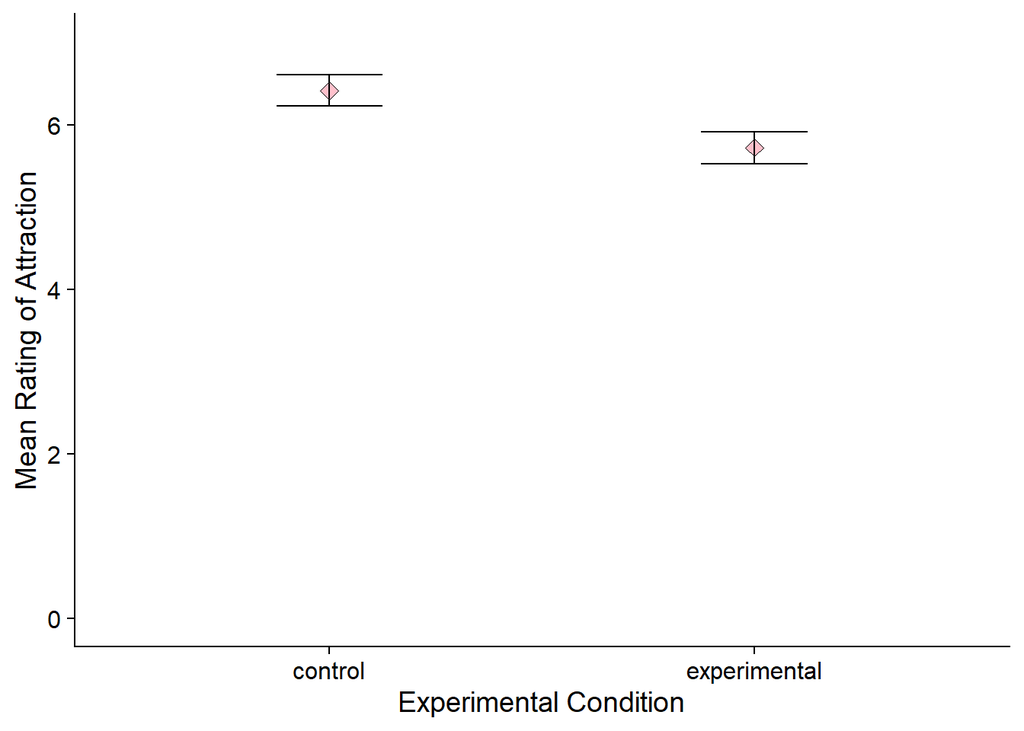

Figure 1. Mean rating of attraction grouped by experimental group.

# Discussion

My results show that the control group gave higher ratings of attractiveness than the experimental group did. This finding is different to that of the original paper by Elliot et al. (2010), as they found that the presence of the colour red caused higher attractiveness ratings. This difference in results suggests that the ‘red effect’ is not a stable one and may not be replicable. However, just comparing my results to the Elliot et al. (2010) results is not valid as there could be a publication bias, and so the results may not be reliable (Francis, 2013), so I am going to look at some other studies to see how my results compare.

Hesslinger, Goldback, and Carbon (2015) replicated one of Elliot et al.’s (2010) studies using the same image and same set of questions. Their results showed no significant effect of the colour red on percieved attractiveness. They then did another experiment where they added apparel style as another factor, and used pictures of 32 different men rather than just one. In this experiment, they only found an effect for apparel style, and no significant effect for the colour red. Elliot and Maier (2013) also replicated their third experiment and didn’t find a significant red effect either, even though they used a larger sample. Peperkoorn, Roberts, and Poller (2016) did three seperate experiments to test the red effect. Their results did not reflect the hypothesis that women in red would be rated by men as the most attractive, as their first two experiments did not show any significant colour effects. They also replicated an experiment by Pazda et al. (2012) but did not find any evidence for the red effect, even though the original study did.

# References

Elliot, A. J., Kayser, D. N., Greitemeyer, T., Lichtenfeld, S., Gramzow, R. H., Maier, M. A., & Liu, H. (2010). Red, rank, and romance in women viewing men. Journal of Experimental Psychology: General, 139(3), 399–417. doi: 10.1037/a0019689Elliot, A. J., & Maier, M. A. (2013). The red-attractiveness effect, applying the Ioannidis and Trikalinos (2007b) test, and the broader scientific context: A reply to Francis (2013). Journal of Experimental Psychology: General, 142(1), 297–300. doi: 10.1037/a0029592Francis, G. (2013). Publication bias in “Red, rank, and romance in women viewing men”. Journal of Experimental Psychology: General, 142(1), 292–296. doi: 10.1037/a0027923Hesslinger, V. M., Goldbach, L., & Carbon, C.-C. (2015). Men in red: A reexamination of the red-attractiveness effect. Psychonomic Bulletin & Review, 22(4), 1142–1148. doi: 10.3758/s13423-015-0866-8Pazda, A. D., Elliot, A. J., & Greitemeyer, T. (2012). Sexy red: Perceived sexual receptivity mediates the red-attraction relation in men viewing woman. Journal of Experimental Social Psychology, 48(3), 787–790. doi: 10.1016/j.jesp.2011.12.009Peperkoorn, L. S., Roberts, S. C., & Pollet, T. V. (2016). Revisiting the Red Effect on Attractiveness and Sexual Receptivity. Evolutionary Psychology, 14(4), 147470491667384. doi: 10.1177/1474704916673841